# An Analysis of Customer Spend and Product Category-level Engagement

Avinash Vashishtha

### 1.Introduction

Our research is focused on helping a major retailer know their customers better. The goal of the study is to derive insights from the available ‘Customer Full Journey’ datasets relating to customers, transactions, and more. As part of our methodology we plan to clean, tidy, explore, and analyze the datasets we received to finally answer the following questions of interest -

- **Problem Statement #1:** What household demographic factors contribute most to customer spend in the stores? Learn about the most impactful factors affecting customer spending.
- **Problem Statement #2:** What category is each customer most engaged with? Profile customers and their engagement levels with product categories.

Our methodology can be broadly classified into three steps -

- **Data cleaning and preparation**: Clean and tidy the tables/datasets in R, and join tables as required for the analysis (more in detail in the section on data preparation)
- **Data Exploration**: Explore the nature and source of data, explore missing values and reasons ; identify abnormal values and outliers, and visualize variable distributions and correlation as required
- **Data Analysis**: We propose a regression analysis (linear modeling) to determine the demographic factors that affect consumer spending the most. This will be followed by a clustering technique to segment and profile customers according to their engagement levels with various product categories inside the store

This research will help the client in two major ways. Firstly, understand better as to what factors impact the amount of purchase customers make inside stores. Secondly, design better targeted marketing campaigns powered by the knowledge of customer engagement (and spending) levels with various product categories.

### 2.Packages

**Packages to be installed**

*Following Packages are needed for the project-*

- **dplyr** - To do data manipulation in R ; Functions- inner_join,glimpse,group_by,summarise,select
- **magrittr** -To use %>% function in the code
- **tidyr** -Included for data tidying ; Functions-To use gather and spread function
- **stats** -Included for statistical functions ; Functions- To use linear regression(ln) and k-means function
- **ggplot2** - To create Data Visualisations ; Functions- Plot
- **factoextra** - To create Data Visualisations for K-means ; Functions- fviz_cluster
- **knitr** - To do formatting in R markdown ; Functions- kable
- **kableExtra** - To do formatting in R markdown
- **Purrr** - To make the codes more efficient using functions like map_*

```r
suppressWarnings(suppressMessages(library(dplyr)))
suppressWarnings(suppressMessages(library(magrittr)))
suppressWarnings(suppressMessages(library(tidyr)))
suppressWarnings(suppressMessages(library(ggplot2)))
suppressWarnings(suppressMessages(library(stats)))
suppressWarnings(suppressMessages(library(factoextra)))
suppressWarnings(suppressMessages(library(knitr)))
suppressWarnings(suppressMessages(library(kableExtra)))
suppressWarnings(suppressMessages(library(purrr)))
```

### 3.1.Data Preparation - I

**3.1. Data Source** The original data on the retail client was downloaded from the Data Wrangling course folders on Github

**3.2.1 Introduction of source data** The dataset primarily tracks the transaction level data from 2,500 households who frequently shop at the client’s stores. Moreover, the data captures purchases made across the entire gamut of product categories available at the retailer’s stores. Among other important information, we have customer demographics data and direct marketing campaigns data available for certain households. (Please Note: The terms ‘Customer’ and ‘Household’ have been assumed synonymous and used interchangeably in this report)

Timeline: The data tracks customer transactions over a period of two years (104 weeks).

**3.2.2 Explanation of source data (tables and variables)** In total, this comprehensive total customer journey had 8 different data frames. Each of these are described in brief below. Also a small glimpse into each of these data is given below

*Code for Loading Tables*

```r
datasets<-c("campaign_desc","campaign_table","causal_data","coupon","coupon_redempt","hh_demographic","product","transaction_data","product_dpt_mapping")
for (i in seq_along(datasets))
{

  file_path=paste0("data/",datasets[i],".csv")
  if(file.exists(file_path))
  {
    df<-read.csv(file_path)
    assign(datasets[i],df)
  } else
    print("No such file exits")
}
```

- **Transaction data**: Variables: This data frame captures all the product purchases done by all households in two years. This data frame has some variables which are of interest to our research question - the sales value, the retail discounts and coupon discounts which will help us arrive at final customer spend for each customer.

| household_key | basket_id | day | product_id | quantity | sales_value | store_id | retail_disc | trans_time | week_no | coupon_disc | coupon_match_disc |
| --- | --- | --- | --- | --- | --- | --- | --- | --- | --- | --- | --- |
| 2375 | 26984851472 | 1 | 1004906 | 1 | 1.39 | 364 | -0.6 | 1631 | 1 | 0 | 0 |
| 2375 | 26984851472 | 1 | 1033142 | 1 | 0.82 | 364 | 0.0 | 1631 | 1 | 0 | 0 |
| 2375 | 26984851472 | 1 | 1036325 | 1 | 0.99 | 364 | -0.3 | 1631 | 1 | 0 | 0 |

- **Demographics data** Shows demographics information on a limited number of households. This will be crucial in solving our problem statement # 1, where we will build a linear model to see what demographic factors affect customer spend.

| household_key | age_desc | marital_status_code | income_desc | homeowner_desc | hh_comp_desc | household_size_desc | kid_category_desc |
| --- | --- | --- | --- | --- | --- | --- | --- |
| 1 | 65+ | A | 35-49K | Homeowner | 2 Adults No Kids | 2 | None/Unknown |
| 7 | 45-54 | A | 50-74K | Homeowner | 2 Adults No Kids | 2 | None/Unknown |
| 8 | 25-34 | U | 25-34K | Unknown | 2 Adults Kids | 3 | 1 |

- **Campaign_table** Lists the campaign received by each household.

| description | household_key | campaign |
| --- | --- | --- |
| TypeA | 17 | 26 |
| TypeA | 27 | 26 |
| TypeA | 212 | 26 |

- **Campaign description** Describes the length of campaigns. Length affects coupon validity period.

| description | campaign | start_day | end_day |
| --- | --- | --- | --- |
| TypeB | 24 | 659 | 719 |
| TypeC | 15 | 547 | 708 |
| TypeB | 25 | 659 | 691 |

| product_id | manufacturer | department | brand | commodity_desc | sub_commodity_desc | curr_size_of_product |
| --- | --- | --- | --- | --- | --- | --- |
| 25671 | 2 | GROCERY | National | FRZN ICE | ICE - CRUSHED/CUBED | 22 LB |
| 26081 | 2 | MISC. TRANS. | National | NO COMMODITY DESCRIPTION | NO SUBCOMMODITY DESCRIPTION |  |
| 26093 | 69 | PASTRY | Private | BREAD | BREAD:ITALIAN/FRENCH |  |

- **Coupon Table** Lists all kinds of coupons given as part of various campaigns to customers. Also mentions the kind of products against which the coupons are redeemable.

| coupon_upc | product_id | campaign |
| --- | --- | --- |
| 10000089061 | 27160 | 4 |
| 10000089064 | 27754 | 9 |
| 10000089073 | 28897 | 12 |

- **Coupon Redemption Table** Lists the coupons that each household/customer redeemed.

| household_key | day | coupon_upc | campaign |
| --- | --- | --- | --- |
| 1 | 421 | 10000085364 | 8 |
| 1 | 421 | 51700010076 | 8 |
| 1 | 427 | 54200000033 | 8 |

- **Causal Data Table** Signifies whether each product was featured/advertised in a weekly mailer or in some in-store display.

| product_id | store_id | week_no | display | mailer |
| --- | --- | --- | --- | --- |
| 26190 | 286 | 70 | 0 | A |
| 26190 | 288 | 70 | 0 | A |
| 26190 | 289 | 70 | 0 | A |

**3.2.3 Peculiarities in the data sets**

*Missing Values -*

```r
for (i in seq_along(datasets))
{
missing_values<-any(is.na(get(datasets[i])))
if (missing_values)
{

  print(paste(datasets[i],"has Missing values"))
} else
  print(paste(datasets[i],"has no Missing values"))
}
```

```
## [1] "campaign_desc has no Missing values"
## [1] "campaign_table has no Missing values"
## [1] "causal_data has no Missing values"
## [1] "coupon has no Missing values"
## [1] "coupon_redempt has no Missing values"
## [1] "hh_demographic has no Missing values"
## [1] "product has no Missing values"
## [1] "transaction_data has no Missing values"
## [1] "product_dpt_mapping has no Missing values"
```

**Note:**

- We see that there are no missing values in the datasets
- We will again do a missing values analysis and an outlier or abnormal values analysis on our variables of concern, on the datasets that we prepare for our problem statements #1 and #2 (in the next tab)

**SUMMARY**:

We showed above a glimpse and summary of how all the data from this comprehensive and complex collection look and what they mean. For solving our two research questions the tables that contain variables ofinterest would be -

- Transaction data
- Product data
- Demographics data

Refer to tab Data preparation II for more on this and next steps…

### 3.3.Data Preparation - II

**3.3. Data Preparation Steps**

Here we focus on two areas, data preparation (slicing and dicing) for:

- Problem Statement #1
- Problem Statement #2

*Problem Statement #1*

**Tables of concern for Problem #1:**

- Transaction data
- Demographic data

**Variables of concern**

**3.4. Methodology and Output dataset**

```r
#Dataset 1-Demographic factors driving customer spend
Demographic_factors<-group_by(transaction_data,household_key) %>%
 summarise(Total_Sales=sum(sales_value))%>%
 inner_join(hh_demographic,by="household_key")
```

| household_key | Total_Sales | age_desc | marital_status_code | income_desc | homeowner_desc | hh_comp_desc | household_size_desc | kid_category_desc |
| --- | --- | --- | --- | --- | --- | --- | --- | --- |
| 1 | 4330.16 | 65+ | A | 35-49K | Homeowner | 2 Adults No Kids | 2 | None/Unknown |
| 7 | 3400.05 | 45-54 | A | 50-74K | Homeowner | 2 Adults No Kids | 2 | None/Unknown |
| 8 | 5534.97 | 25-34 | U | 25-34K | Unknown | 2 Adults Kids | 3 | 1 |
| 13 | 13190.92 | 25-34 | U | 75-99K | Homeowner | 2 Adults Kids | 4 | 2 |
| 16 | 1512.02 | 45-54 | B | 50-74K | Homeowner | Single Female | 1 | None/Unknown |

```
##  household_key   Total_Sales       age_desc   marital_status_code
##  Min.   :   1   Min.   :  646.4   19-24: 46   A:340
##  1st Qu.: 596   1st Qu.: 2970.1   25-34:142   B:117
##  Median :1218   Median : 4676.4   35-44:194   U:344
##  Mean   :1235   Mean   : 5615.1   45-54:288
##  3rd Qu.:1914   3rd Qu.: 7165.0   55-64: 59
##  Max.   :2499   Max.   :27859.7   65+  : 72
##
##     income_desc          homeowner_desc           hh_comp_desc
##  50-74K   :192   Homeowner      :504    1 Adult Kids    : 47
##  35-49K   :172   Probable Owner : 11    2 Adults Kids   :187
##  75-99K   : 96   Probable Renter: 11    2 Adults No Kids:255
##  25-34K   : 77   Renter         : 42    Single Female   :144
##  15-24K   : 74   Unknown        :233    Single Male     : 95
##  Under 15K: 61                          Unknown         : 73
##  (Other)  :129
##  household_size_desc    kid_category_desc
##  1 :255              1           :114
##  2 :318              2           : 60
##  3 :109              3+          : 69
##  4 : 53              None/Unknown:558
##  5+: 66
##
##
```

*Problem Statement #2*

**Tables of concern for Problem #2:**

- Transaction data
- Product data

**Variables of concern**

- *Total_Sales*: signifies the total customer spend, as per current understanding.
- *household_key*: signifies a unique customer
- *product categories*: the categories classified into

```r
#Dataset 2-Profiling of Customers based on Product Category Engagement
Customer_profile <- inner_join(transaction_data, product, by = "product_id")%>%
  inner_join(product_dpt_mapping, by = "department")%>%
  group_by(household_key, Super_category) %>%
  summarise(Total_Sales = sum(sales_value))%>%
  select(household_key, Super_category, Total_Sales)%>%
  spread(Super_category, Total_Sales)
```

| household_key | AUTOMOTIVE | COSMETICS | COUPONS | DELI | EGGS & MILK PRODUCTS | FLORAL | GARDEN SUPPLIES | GROCERY | GROCERY-HEALTHY | INFANT PRODUCTS | LIQUIOR | MEAT | MISC ITEMS | PHARMACY | SERVICES | STATIONARY | STORE SUPPLY/MISC | TOYS | VIDEO |
| --- | --- | --- | --- | --- | --- | --- | --- | --- | --- | --- | --- | --- | --- | --- | --- | --- | --- | --- | --- |
| 1 | NA | NA | 20.00 | 212.17 | NA | 7.99 | NA | 3021.10 | 48.33 | NA | NA | 349.00 | 530.89 | NA | 140.68 | NA | NA | NA | NA |
| 2 | NA | 22.07 | 4.26 | 46.73 | NA | 21.99 | NA | 1264.77 | 7.47 | NA | NA | 232.19 | 330.04 | NA | 24.82 | NA | NA | NA | NA |
| 3 | NA | 1.25 | NA | 36.47 | NA | NA | NA | 1852.78 | NA | NA | NA | 578.97 | 179.09 | NA | 4.65 | NA | NA | NA | NA |
| 4 | NA | 2.12 | NA | 14.35 | NA | NA | NA | 703.60 | 3.29 | NA | NA | 157.77 | 318.98 | NA | NA | NA | NA | NA | NA |
| 5 | NA | 9.48 | NA | 80.03 | NA | NA | NA | 361.32 | 2.00 | NA | NA | 120.77 | 203.08 | NA | 2.38 | NA | NA | NA | NA |

```
##  household_key      AUTOMOTIVE       COSMETICS         COUPONS
##  Min.   :   1.0   Min.   : 0.000   Min.   :  0.00   Min.   :    0.00
##  1st Qu.: 625.8   1st Qu.: 2.950   1st Qu.:  4.01   1st Qu.:    3.49
##  Median :1250.5   Median : 5.950   Median : 10.80   Median :   10.50
##  Mean   :1250.5   Mean   : 7.421   Mean   : 25.16   Mean   :   80.34
##  3rd Qu.:1875.2   3rd Qu.: 9.990   3rd Qu.: 29.12   3rd Qu.:   37.97
##  Max.   :2500.0   Max.   :33.660   Max.   :529.07   Max.   :11161.12
##                   NA's   :2439     NA's   :1214     NA's   :994
##       DELI         EGGS & MILK PRODUCTS     FLORAL       GARDEN SUPPLIES
##  Min.   :   0.75   Min.   :0.5000       Min.   :  0.00   Min.   :  0.00
##  1st Qu.:  21.76   1st Qu.:0.8975       1st Qu.:  8.99   1st Qu.:  5.00
##  Median :  56.66   Median :0.9500       Median : 18.98   Median : 13.34
##  Mean   : 116.06   Mean   :1.4646       Mean   : 33.43   Mean   : 24.90
##  3rd Qu.: 137.72   3rd Qu.:1.7600       3rd Qu.: 38.95   3rd Qu.: 29.86
##  Max.   :1808.36   Max.   :5.7800       Max.   :877.12   Max.   :936.67
##  NA's   :252       NA's   :2450         NA's   :1314     NA's   :2192
##     GROCERY         GROCERY-HEALTHY   INFANT PRODUCTS    LIQUIOR
##  Min.   :    1.74   Min.   :   0.00   Min.   :2.020   Min.   :   0.000
##  1st Qu.:  558.17   1st Qu.:   5.00   1st Qu.:2.020   1st Qu.:   8.735
##  Median : 1267.53   Median :  13.78   Median :2.355   Median :  17.480
##  Mean   : 1862.72   Mean   :  56.82   Mean   :2.355   Mean   :  38.492
##  3rd Qu.: 2575.04   3rd Qu.:  43.01   3rd Qu.:2.690   3rd Qu.:  34.020
##  Max.   :15047.67   Max.   :5535.49   Max.   :2.690   Max.   :2642.020
##                     NA's   :781       NA's   :2496    NA's   :1937
##       MEAT           MISC ITEMS        PHARMACY         SERVICES
##  Min.   :   1.71   Min.   :   0.0   Min.   : 1.190   Min.   :  0.00
##  1st Qu.: 102.86   1st Qu.: 120.2   1st Qu.: 5.910   1st Qu.: 14.99
##  Median : 274.07   Median : 310.3   Median : 6.990   Median : 39.44
##  Mean   : 427.87   Mean   : 646.0   Mean   : 9.804   Mean   : 66.60
##  3rd Qu.: 571.49   3rd Qu.: 800.3   3rd Qu.:11.748   3rd Qu.: 83.27
##  Max.   :3708.78   Max.   :7939.3   Max.   :20.890   Max.   :885.24
##  NA's   :37        NA's   :7        NA's   :2482     NA's   :177
##    STATIONARY    STORE SUPPLY/MISC      TOYS          VIDEO
##  Min.   :1.000   Min.   : 0.000    Min.   :0.99   Min.   : 5.000
##  1st Qu.:2.435   1st Qu.: 1.000    1st Qu.:0.99   1st Qu.: 6.482
##  Median :3.870   Median : 1.000    Median :1.24   Median : 9.235
##  Mean   :3.870   Mean   : 2.453    Mean   :2.46   Mean   : 9.372
##  3rd Qu.:5.305   3rd Qu.: 1.000    3rd Qu.:2.71   3rd Qu.:12.213
##  Max.   :6.740   Max.   :20.000    Max.   :6.37   Max.   :13.990
##  NA's   :2498    NA's   :2480      NA's   :2496   NA's   :2494
```

**3.5. Variables Summary:**

**Missing Values** : There are no missing values. However the NA values might give the reader the wrong idea. To clarify, for the purposes of our analysis, an *‘NA’ would mean zero spending for the particular customer in that particular category. So, the NA values would be imputed with zeroes before starting analysis*

### 4.1.Data Analysis: Problem-1

*4.1 Problem Statement 1-Demographic factors driving customer spend*

- **4.1.1 Analysis**

Here is the main analysis of our first problem statement - What factors primarily affect the total customer spending for our retail client. The analysis is being done on the dataset - ‘Demographic_factors’. The reader might remember that this dataset in the one we prepared (using wrangling procedures) in our data preparation sections I and II. The predictor variables being investigated are income_desc, household_size_desc, marital_status_code, and age_desc and all of these are ‘factors’

To begin with, the analysis “graphically” investigates the possible effects of these variables on the customer spend (Total_Sales). Along with the plots, an interpretation of plots is provided. This is followed by a linear model on the Total_Sales against the four predictor variables, along with interpretations. At the very last of this section, we present a paragraph on the summary/explanation of results.

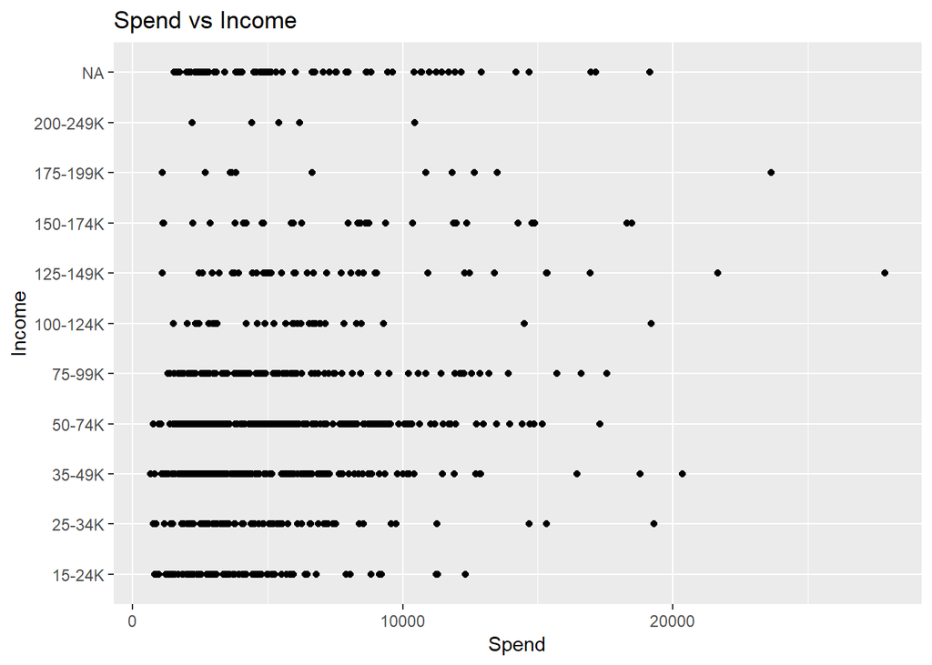

```r
Demographic_factors %>%
  ggplot(aes(x = Total_Sales, y = income_desc)) +
  geom_point() +
  labs(title = "Spend vs Income", x = "Spend", y = "Income")
```

**Observation:** We see that the average consumer spend looks to be the highest in the age group of $50-74k followed by the age groups of $35-49k and $75-99k.

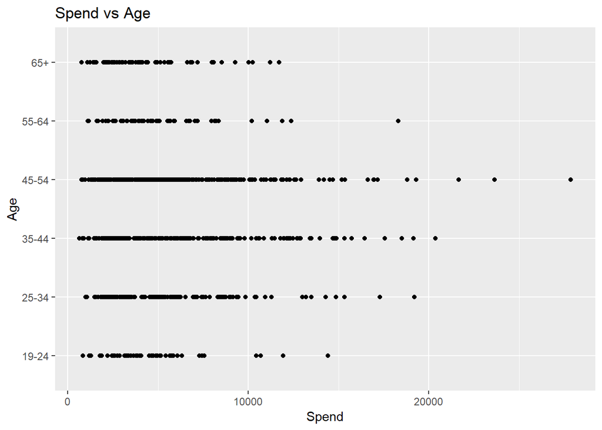

```r
Demographic_factors %>%
ggplot(aes(x = Total_Sales, y = age_desc)) +
  geom_point() +
  labs(title = "Spend vs Age", x = "Spend", y = "Age")
```

**Observation:** It appears that the age bracket of 35-55 years spends the highest compared to all other age groups.

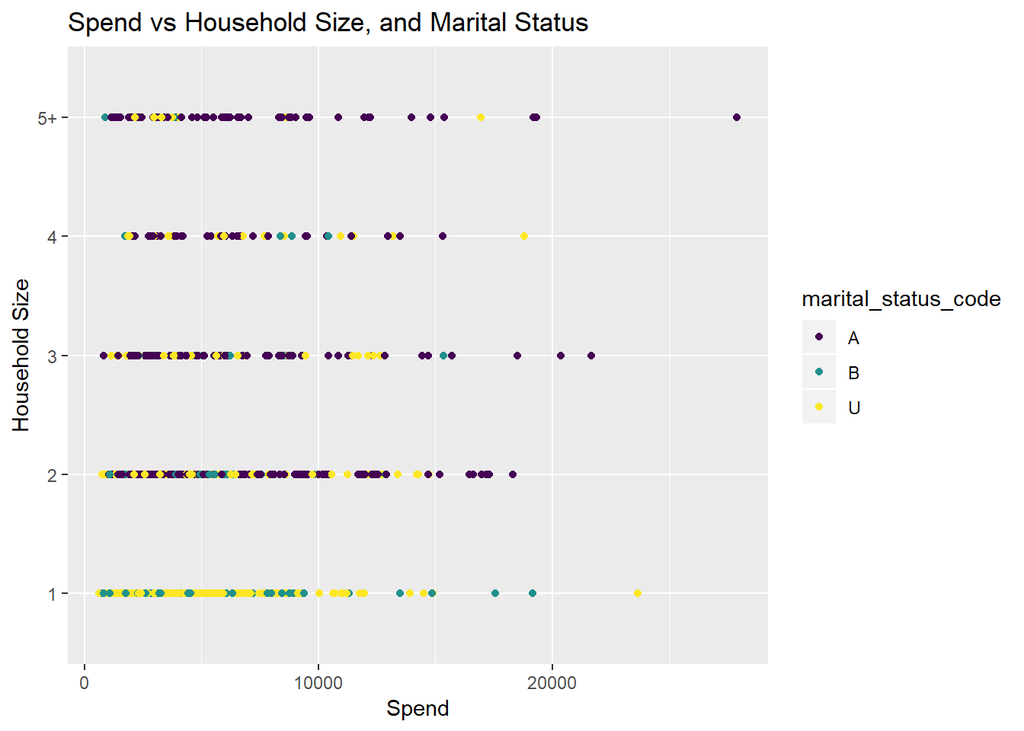

```r
Demographic_factors %>%
ggplot(aes(x = Total_Sales, y = household_size_desc,
                                color = marital_status_code)) +
  geom_point() +
  labs(title = "Spend vs Household Size, and Marital Status", x = "Spend",
       y = "Household Size")
```

**Observation:** It appears that households with sizes of 2 and 3 would be the highest average spenders, followed by households with sizes 1 and 5. Moreover, it also appears that on average, married customers do spend more as compared to unmarried and single people.

From the above, we conjecture that a consumer profile who is married, has an household size of 2 to 3, is in the age bracket of 35 to 55, and earns $50-74k per annum, will likely be the highest average spender for our client. We explore it a little further though a linear regression model as follows.

Since all our predictor variables are factors, we take the following steps before running a regression-

- Dummy encoding before running our regression
- Check to make sure our response variable can be reasonably assumed to be normally distributed

```r
# Dummy encoding

head(model.matrix( ~  age_desc + marital_status_code + income_desc +
                     household_size_desc, data = Demographic_factors))
```

[output not shown]

```r
# Regression

model_1 <- lm(Total_Sales ~ age_desc + marital_status_code +
                           income_desc + household_size_desc,
                         data = Demographic_factors)
summary(model_1)
```

```
##
## Call:
## lm(formula = Total_Sales ~ age_desc + marital_status_code + income_desc +
##     household_size_desc, data = Demographic_factors)
##
## Residuals:
##     Min      1Q  Median      3Q     Max
## -7400.3 -2450.4  -639.5  1497.9 19669.4
##
## Coefficients:
##                       Estimate Std. Error t value Pr(>|t|)
## (Intercept)             4994.1      688.4   7.255 1.06e-12 ***
## age_desc25-34            708.0      683.6   1.036  0.30072
## age_desc35-44           1400.9      670.2   2.090  0.03695 *
## age_desc45-54            782.6      650.4   1.203  0.22931
## age_desc55-64            223.6      783.8   0.285  0.77555
## age_desc65+             -334.1      755.6  -0.442  0.65852
## marital_status_code.L   -228.9      253.7  -0.902  0.36729
## marital_status_code.Q    216.0      324.2   0.666  0.50543
## income_desc.L           3102.2      954.3   3.251  0.00121 **
## income_desc.Q          -1245.2      926.4  -1.344  0.17933
## income_desc.C          -1936.3      840.4  -2.304  0.02151 *
## income_desc^4          -1989.2      798.6  -2.491  0.01297 *
## income_desc^5           -615.0      733.4  -0.839  0.40202
## income_desc^6            -82.5      647.3  -0.127  0.89862
## income_desc^7            301.8      554.4   0.544  0.58638
## income_desc^8           -614.2      483.7  -1.270  0.20464
## income_desc^9           -179.3      487.4  -0.368  0.71315
## household_size_desc2     233.2      369.4   0.631  0.52806
## household_size_desc3     678.9      478.5   1.419  0.15641
## household_size_desc4    1138.8      614.4   1.854  0.06421 .
## household_size_desc5+    735.5      599.1   1.228  0.21995
## ---
## Signif. codes:  0 '***' 0.001 '**' 0.01 '*' 0.05 '.' 0.1 ' ' 1
##
## Residual standard error: 3517 on 708 degrees of freedom
##   (72 observations deleted due to missingness)
## Multiple R-squared:  0.1209, Adjusted R-squared:  0.09608
## F-statistic: 4.869 on 20 and 708 DF,  p-value: 2.833e-11
```

*4.1.2 Methodology*

**4.1.2.a Preliminary Analysis** - Summaries (*Mean, Median*) across various demographic variables were calculated to understand how spend varies across different levels. Also, we did a graphical investigation to see patterns, and correlations.

Once we had some idea about how various variables affect consumer spend, a linear regression model was built to ascertain which variables categories affect spending and how they affect spending.

**4.1.2.b Linear Regression Model** - We built a Linear Regression model using the dataset with all demographic variables and overall sales. Following steps were followed-

- *Step 1*-Data was collated with all the demographic variables and overall sales over a certain time period for all customers
- *Step 2*-After checking relationships of variables with overall sales(*Using plots of predictors and sales*), we tested appropriateness for normality of the response variable. And we followed a dummy encoding for all the factor predictor variables.
- *Step 3*-Once these validations were complete, we ran the linear regression to calculate estimates for each of the variables and categories
- *Step 4*-Compare the model iteration using model-fit statistics(*R-square, error*) to arrive at the best model
- *Step 5*-Calculate the contribution values to understand to what magnitude is sales affected by each of those demographic factors.

### 4.2.Data Analysis: Problem-2

*4.2 Problem Statement 2-Profiling of Customers based on Product Category Engagement*

**4.2.1 Data Sources used-**

- Transaction Data
- Product Data

**4.2.2 Business Problem**- Segmenting customers based on spend across various product categories

**4.2.3 Data Analysis** -

**4.2.3.a Preliminary Analysis**- Summarize(*mean,median and mode*) the datasets and plot using box-plot graph to identify outliers in spend data. Calculated the range of spend that should be considered after removing outliers. Using plots thus created, identify categories which are more important that others.

**4.2.3.b K-Means Segmentation** - Using sales value across many product departments, K-means segmentation was done to segment customers based on their product needs. Following steps were followed-

- **Step 1** - Required columns(*Household ids, Total Sales, Product Categories/Departments*) were pulled from Transaction and Product data after merging them using appropriate columns
- **Step 2** - Using the product description information, similar product categories(department) were combined to form broad product categories. *e.g. ‘Frozen grocery’, ‘Produce’ and ‘Grocery’ were all combined under Grocery*
- **Step 3** - Sales values were rolled up at broad product category level to get total sales for the households
- **Step 4** -Data was transformed from tall to wide format where columns have total sales for the product categories

| household_key | AUTOMOTIVE | COSMETICS | COUPONS | DELI | EGGS & MILK PRODUCTS | FLORAL | GARDEN SUPPLIES | GROCERY | GROCERY-HEALTHY | INFANT PRODUCTS | LIQUIOR | MEAT | MISC ITEMS | PHARMACY | SERVICES | STATIONARY | STORE SUPPLY/MISC | TOYS | VIDEO |
| --- | --- | --- | --- | --- | --- | --- | --- | --- | --- | --- | --- | --- | --- | --- | --- | --- | --- | --- | --- |
| 1 | NA | NA | 20.00 | 212.17 | NA | 7.99 | NA | 3021.10 | 48.33 | NA | NA | 349.00 | 530.89 | NA | 140.68 | NA | NA | NA | NA |
| 2 | NA | 22.07 | 4.26 | 46.73 | NA | 21.99 | NA | 1264.77 | 7.47 | NA | NA | 232.19 | 330.04 | NA | 24.82 | NA | NA | NA | NA |
| 3 | NA | 1.25 | NA | 36.47 | NA | NA | NA | 1852.78 | NA | NA | NA | 578.97 | 179.09 | NA | 4.65 | NA | NA | NA | NA |
| 4 | NA | 2.12 | NA | 14.35 | NA | NA | NA | 703.60 | 3.29 | NA | NA | 157.77 | 318.98 | NA | NA | NA | NA | NA | NA |
| 5 | NA | 9.48 | NA | 80.03 | NA | NA | NA | 361.32 | 2.00 | NA | NA | 120.77 | 203.08 | NA | 2.38 | NA | NA | NA | NA |
| 6 | NA | 9.96 | 17.99 | 125.23 | NA | 23.98 | 8.58 | 3288.33 | 46.19 | NA | NA | 1213.28 | 1097.23 | NA | 165.39 | NA | NA | NA | NA |

[output not shown]

[output not shown]

[output not shown]

[output not shown]

[output not shown]

[output not shown]

[output not shown]

[output not shown]

[output not shown]

[output not shown]

Total sales across product category suggests that biggest product category is Grocery followed by Misc Items and Meat. These 19 variables were taken as input for K-means clustering

| product | Sum_cols |
| --- | --- |
| GROCERY | 4656794.40 |
| MISC ITEMS | 1610363.09 |
| MEAT | 1053836.82 |
| DELI | 260902.59 |
| SERVICES | 154722.32 |
| COUPONS | 120987.76 |
| GROCERY-HEALTHY | 97669.04 |
| FLORAL | 39653.34 |
| COSMETICS | 32360.37 |
| LIQUIOR | 21670.88 |
| GARDEN SUPPLIES | 7667.82 |
| AUTOMOTIVE | 452.66 |
| PHARMACY | 176.48 |
| EGGS & MILK PRODUCTS | 73.23 |
| VIDEO | 56.23 |
| STORE SUPPLY/MISC | 49.05 |
| TOYS | 9.84 |
| INFANT PRODUCTS | 9.42 |
| STATIONARY | 7.74 |

Histogram of all 2500 households and their overall spend

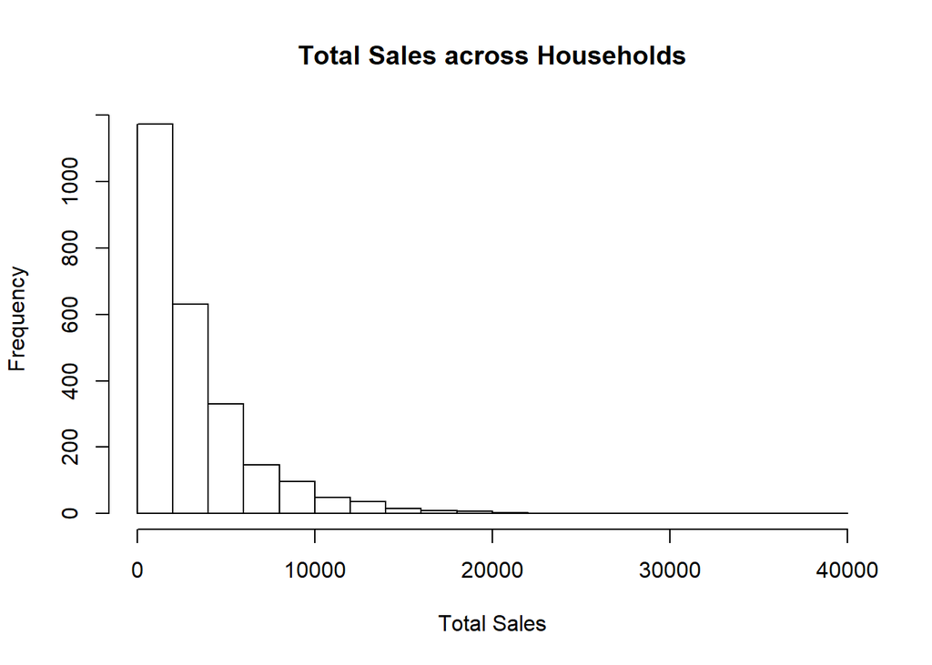

Checking quantile values to understand what should be the cut-off for analysis.Customers who spent less than $390 in 2 years time were removed from the analysis as we dont have sufficient history for those cases

```
##      10%      50%      90%
##  389.878 2157.750 7448.216
```

* **Step 5** -Total Sales values were standardized to give similar weightage to all product categories

| GROCERY | MISC ITEMS | MEAT | DELI | SERVICES | COUPONS | GROCERY-HEALTHY | FLORAL | COSMETICS | LIQUIOR | GARDEN SUPPLIES | AUTOMOTIVE | PHARMACY | EGGS & MILK PRODUCTS | VIDEO | STORE SUPPLY/MISC | TOYS | INFANT PRODUCTS | STATIONARY |
| --- | --- | --- | --- | --- | --- | --- | --- | --- | --- | --- | --- | --- | --- | --- | --- | --- | --- | --- |
| 0.5112524 | -0.1974663 | -0.2465622 | 0.5824087 | 0.8392364 | -0.1025096 | 0.0317165 | -0.2309761 | -0.4367516 | -0.1416004 | -0.1467752 | -0.1227636 | -0.0746371 | -0.1192238 | -0.0448826 | -0.044699 | -0.0310159 | -0.0417706 | -0.0239491 |
| -0.4182378 | -0.4174619 | -0.4940023 | -0.4104241 | -0.4943611 | -0.1505816 | -0.2160162 | 0.1119995 | 0.2405165 | -0.1416004 | -0.1467752 | -0.1227636 | -0.0746371 | -0.1192238 | -0.0448826 | -0.044699 | -0.0310159 | -0.0417706 | -0.0239491 |
| -0.1070494 | -0.5828009 | 0.2405860 | -0.4719961 | -0.7265263 | -0.1635922 | -0.2613066 | -0.4267171 | -0.3983925 | -0.1416004 | -0.1467752 | -0.1227636 | -0.0746371 | -0.1192238 | -0.0448826 | -0.044699 | -0.0310159 | -0.0417706 | -0.0239491 |
| -0.7152218 | -0.4295762 | -0.6516471 | -0.6047419 | -0.7800498 | -0.1635922 | -0.2413594 | -0.4267171 | -0.3716946 | -0.1416004 | -0.1467752 | -0.1227636 | -0.0746371 | -0.1192238 | -0.0448826 | -0.044699 | -0.0310159 | -0.0417706 | -0.0239491 |
| -0.8963643 | -0.5565241 | -0.7300246 | -0.2105853 | -0.7526549 | -0.1635922 | -0.2491806 | -0.4267171 | -0.1458363 | -0.1416004 | -0.1467752 | -0.1227636 | -0.0746371 | -0.1192238 | -0.0448826 | -0.044699 | -0.0310159 | -0.0417706 | -0.0239491 |
| 0.6526767 | 0.4228588 | 1.5842527 | 0.0606674 | 1.1236590 | -0.1086484 | 0.0187418 | 0.1607510 | -0.1311064 | -0.1416004 | 0.2242823 | -0.1227636 | -0.0746371 | -0.1192238 | -0.0448826 | -0.044699 | -0.0310159 | -0.0417706 | -0.0239491 |

* **Step 6** -Decide cluster count such that the total intra-cluster variation(within cluster sum of squares) is minimized. *15 was taken as the optimal cluster count from the graph*

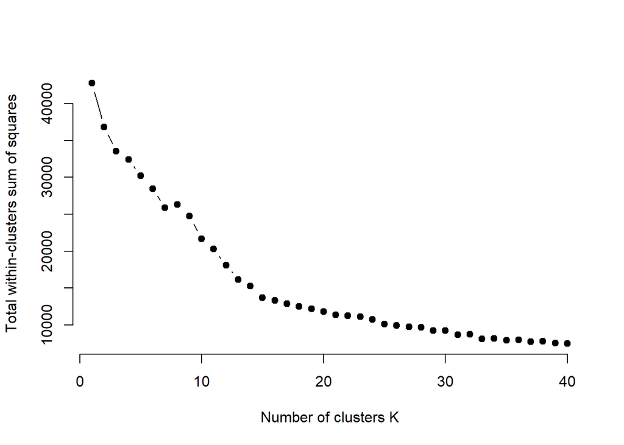

```r
# function to compute total within-cluster sum of square
wss <- function(k) {
  kmeans(df, k, nstart = 10 )$tot.withinss
}
# Compute and plot wss for k = 1 to k = 40
k.values <- 1:40

# extract wss for 1-40 clusters
wss_values <- suppressWarnings(map_dbl(k.values, wss))
par(mfrow=c(1,1))
suppressWarnings(plot(k.values, wss_values,
     type = "b", pch = 19, frame = FALSE,
     xlab = "Number of clusters K",
     ylab = "Total within-clusters sum of squares"))
```

* **Step 7** -K-means segmentation was run on the standardized columns to make clusters

```r
#running k-means for 15 cluster count
k2 <- suppressWarnings(kmeans(df, centers = 15, nstart = 25))
str(k2)
```

```
## List of 9
##  $ cluster     : int [1:2250] 5 9 9 9 9 5 5 5 9 15 ...
##  $ centers     : num [1:15, 1:19] 1.818 1.083 0.634 6.07 0.255 ...
##   ..- attr(*, "dimnames")=List of 2
##   .. ..$ : chr [1:15] "1" "2" "3" "4" ...
##   .. ..$ : chr [1:19] "GROCERY" "MISC ITEMS" "MEAT" "DELI" ...
##  $ totss       : num 42731
##  $ withinss    : num [1:15] 135 660 115 0 3044 ...
##  $ tot.withinss: num 13725
##  $ betweenss   : num 29006
##  $ size        : int [1:15] 4 9 4 1 639 14 1 10 1238 233 ...
##  $ iter        : int 11
##  $ ifault      : int 2
##  - attr(*, "class")= chr "kmeans"
```

After getting cluster mappind for all 2250 households, data looks like this

```
##   k2$cluster MISC ITEMS GROCERY
## 1          5     530.89 3021.10
## 2          9     330.04 1264.77
## 3          9     179.09 1852.78
## 4          9     318.98  703.60
## 5          9     203.08  361.32
## 6          5    1097.23 3288.33
```

* **Step 8** -Visualize the cluster in R to understand how the customers have been clustered

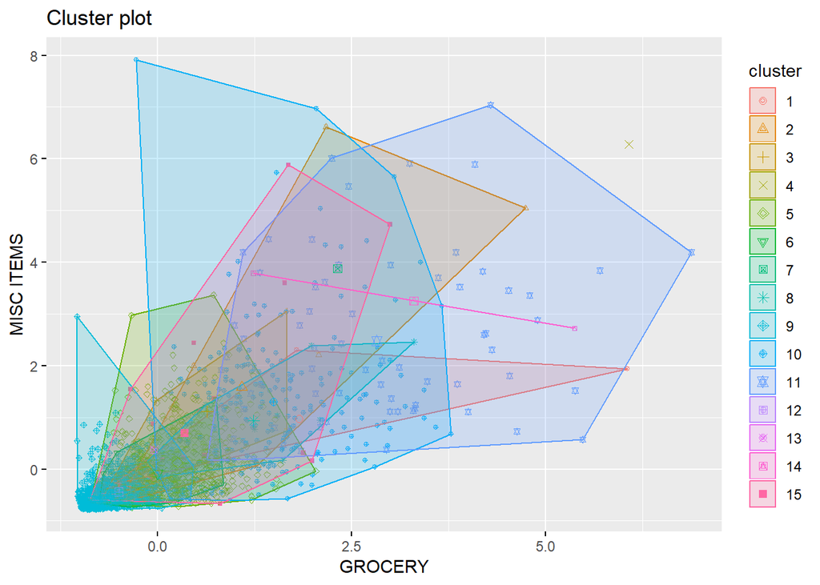

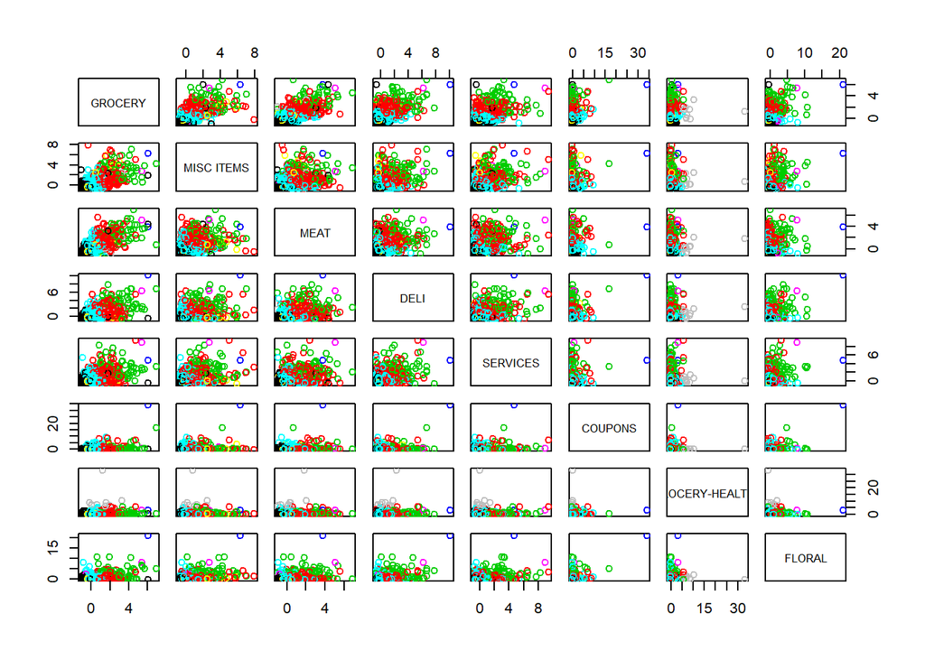

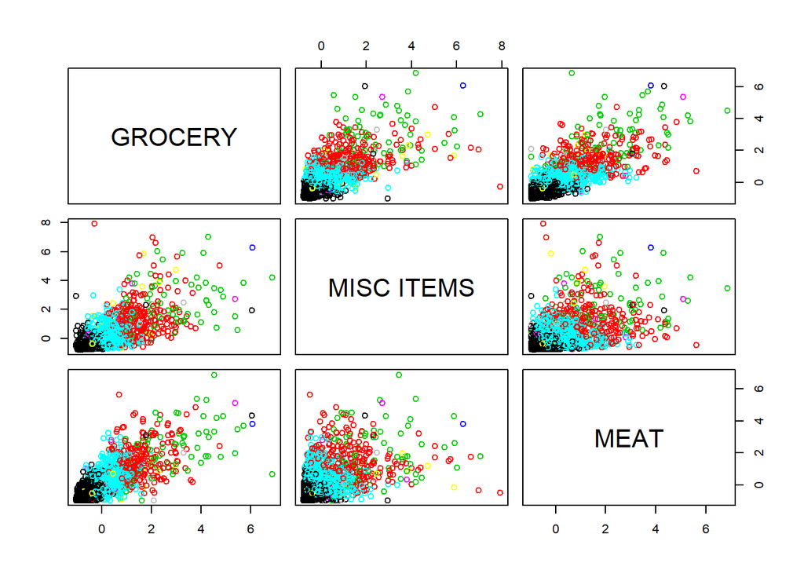

* **Step 9** - Profile and name the clusters based on the average spend across categories. Segments have been named as ‘H-Floral-Cosmetics-Garden Supplies buyers’ where H represents ‘high’ total spend and Product categories names suggests the kind of product a customer/household buys(Check Excel)

| cluster | number | avg_GROCERY | avg_MISC_ITEMS | avg_MEAT | avg_DELI | avg_SERVICES | avg_COUPONS | avg_GROCERY_HEALTHY | avg_FLORAL | avg_COSMETICS | avg_LIQUIOR | avg_GARDEN_SUPPLIES | avg_AUTOMOTIVE | avg_PHARMACY | avg_EGGS___MILK_PRODUCTS | avg_VIDEO | avg_STORE_SUPPLY_MISC | avg_TOYS | avg_INFANT_PRODUCTS | avg_STATIONARY |
| --- | --- | --- | --- | --- | --- | --- | --- | --- | --- | --- | --- | --- | --- | --- | --- | --- | --- | --- | --- | --- |
| 1 | 4 | 5491.0200 | 1600.3275 | 1306.0325 | 88.01500 | 130.56750 | 32.81000 | 37.66250 | 7.060000 | 45.995000 | 26.560000 | 0.0000000 | 0.0000000 | 0.0000000 | 0.4400000 | 0.0000000 | 0.0000000 | 0.0000000 | 2.355 | 0.0000000 |
| 2 | 9 | 4101.6133 | 2158.5800 | 605.4089 | 366.78667 | 270.55222 | 371.75111 | 237.92000 | 69.255556 | 61.822222 | 22.824444 | 19.4611111 | 0.0000000 | 14.9455556 | 0.0000000 | 0.0000000 | 0.0000000 | 0.0000000 | 0.000 | 0.0000000 |
| 3 | 4 | 3253.7375 | 1724.6425 | 779.4725 | 170.92500 | 77.58750 | 12.93500 | 29.20750 | 7.382500 | 7.045000 | 44.657500 | 0.0000000 | 0.0000000 | 0.0000000 | 0.0000000 | 11.3125000 | 0.0000000 | 0.0000000 | 0.000 | 0.0000000 |
| 4 | 1 | 13523.8300 | 6447.2700 | 2263.5500 | 1808.36000 | 476.46000 | 11161.12000 | 563.31000 | 877.120000 | 212.120000 | 49.980000 | 936.6700000 | 0.0000000 | 0.0000000 | 0.0000000 | 0.0000000 | 0.0000000 | 0.0000000 | 0.000 | 0.0000000 |
| 5 | 639 | 2536.0856 | 824.4299 | 587.5830 | 130.32310 | 81.38161 | 58.04653 | 42.63070 | 19.318060 | 15.181847 | 9.443083 | 2.7926604 | 0.0455243 | 0.0077934 | 0.0182942 | 0.0000000 | 0.0236307 | 0.0015493 | 0.000 | 0.0000000 |
| 6 | 14 | 2055.8636 | 638.4293 | 609.9521 | 95.69143 | 66.16429 | 17.66143 | 18.25500 | 17.275714 | 7.216429 | 1.612143 | 6.3478571 | 0.0000000 | 0.0000000 | 2.7821429 | 0.0000000 | 0.0000000 | 0.0000000 | 0.000 | 0.0000000 |
| 7 | 1 | 6432.8600 | 4248.3500 | 888.7000 | 66.23000 | 67.85000 | 2.99000 | 21.24000 | 0.000000 | 46.210000 | 2642.020000 | 0.0000000 | 4.4500000 | 0.0000000 | 0.0000000 | 0.0000000 | 0.0000000 | 0.0000000 | 0.000 | 0.0000000 |
| 8 | 10 | 4385.0750 | 1563.1170 | 586.2970 | 257.82900 | 91.98100 | 35.48300 | 1694.22900 | 39.557000 | 46.844000 | 12.888000 | 5.8440000 | 0.3990000 | 0.5970000 | 0.0000000 | 0.0000000 | 0.0000000 | 0.0000000 | 0.000 | 0.0000000 |
| 9 | 1238 | 904.8305 | 259.3305 | 209.6189 | 42.64703 | 30.48683 | 12.75612 | 16.43466 | 6.333207 | 4.501615 | 5.148215 | 0.7878837 | 0.0296123 | 0.0106381 | 0.0067932 | 0.0040388 | 0.0016155 | 0.0000000 | 0.000 | 0.0000000 |
| 10 | 233 | 4865.4105 | 1895.4209 | 1132.1258 | 293.27983 | 146.18455 | 116.42378 | 78.99468 | 32.853176 | 34.432060 | 15.077296 | 5.8499142 | 0.1380258 | 0.0680687 | 0.0454506 | 0.0000000 | 0.0085837 | 0.0042489 | 0.000 | 0.0042918 |
| 11 | 67 | 7388.5609 | 2969.6737 | 1487.0336 | 582.53433 | 297.20836 | 314.28716 | 130.21716 | 121.321940 | 84.197164 | 24.645373 | 30.8532836 | 0.1035821 | 0.0297015 | 0.0141791 | 0.0000000 | 0.0000000 | 0.0222388 | 0.000 | 0.0000000 |
| 12 | 1 | 1110.0400 | 308.1300 | 326.7800 | 45.86000 | 56.45000 | 11.50000 | 0.00000 | 9.990000 | 2.990000 | 0.000000 | 0.0000000 | 0.0000000 | 0.0000000 | 0.0000000 | 0.0000000 | 0.0000000 | 0.0000000 | 0.000 | 6.7400000 |
| 13 | 1 | 1964.4100 | 1052.5700 | 635.8200 | 13.08000 | 128.90000 | 0.00000 | 4.48000 | 52.970000 | 1.590000 | 59.180000 | 0.0000000 | 0.0000000 | 0.0000000 | 0.0000000 | 0.0000000 | 0.0000000 | 6.3700000 | 0.000 | 0.0000000 |
| 14 | 2 | 8289.2800 | 3683.4000 | 1747.4500 | 736.39000 | 529.16500 | 486.54000 | 274.97500 | 188.185000 | 101.695000 | 18.580000 | 60.7600000 | 0.0000000 | 0.0000000 | 0.0000000 | 0.0000000 | 14.9750000 | 0.0000000 | 0.000 | 0.0000000 |
| 15 | 26 | 2704.9212 | 1344.3535 | 497.9615 | 150.88654 | 71.50192 | 122.01115 | 58.04923 | 22.616923 | 49.244231 | 10.457692 | 2.5196154 | 13.0526923 | 0.0000000 | 0.0000000 | 0.0000000 | 0.0000000 | 0.0000000 | 0.000 | 0.0000000 |

### 5.Summary

We studied two different problem statements. The summary of both are mentioned below, one after the other.

**Problem Statement - 1**

*5.1.1 Problem Statement* The purpose of this study was to understand how the demographic factors like marital status, age, income and household size affect consumer spending. Knowing what demographics make consumers send more during store visits will enable the client’s business to be more customer-centric and to ensure better customer lifetime value

*5.1.2 Methodology*

- **Step 1** Summaries (*Mean, Median*) across various demographic variables were calculated to understand how spend varies across different levels. Also, we did a graphical investigation to see patterns and correlations. Once we had some idea about how various variables affect consumer spend, a linear regression model was built to ascertain which variables categories affect spending and how they affect spending.
- **Step 2** Data was collated with all the demographic variables and overall sales over a certain time period for all customers
- **Step 3** After checking relationships of variables with overall sales(*Using plots of predictors and sales*), we tested appropriateness for normality of the response variable. And we followed a dummy encoding for all the factor predictor variables.
- **Step 4** Once these validations were complete, we ran the linear regression to calculate estimates for each of the variables and categories
- **Step 5** Compare the model iteration using model-fit statistics(*R-square, error*) to arrive at the best model
- **Step 6** Calculate the contribution values to understand to what magnitude is sales affected by each of those demographic factors.

*5.1.3 Interesting Insights!*

*5.1.4 Project Implications*

We feel that this insight on what demographics make consumers spend more will be key to any decision-making for our retail client. This can be a big enabler in any promotion/coupon targeting programs to various consumer segments or to attract those demographic segments of consumers who currently are not high spenders. Overall, we believe this knowledge is key to ensuring a high average customer lifetime value.

**Limitations of the analysis** * This study was limited to the demographic factors we saw in the data. when we ran the regression we found it gave a lower R-square value. We think that there could be other predictor variables that we are not seeing in the data, which might help explain the correlation even better. Variables such as, whether the consumer is a loyal to another retail chain, or whether distance and convenience is a factor how people choose to walk into stores.

**Problem Statement - 2**

*5.2.1 Problem Statement* The purpose of this study was to get better understanding of our retail client’s customers based on product category preferences. It will allow business to get better visibility of the market and customize promotions based on their buying preference. Further, these promotions can help improve the customer interaction level with the store. Over time, it will also allow business to keep track of how customers are moving across defined segments and how their preferences change with time

*5.2.2 Methodology*

Using sales value across many product departments, K-means segmentation was done to segment customers based on their product needs. Following steps were followed-

- **Step 1** - Required columns(*Household ids, Total Sales, Product Categories/Departments*) were pulled from Transaction and Product data after merging them using appropriate columns
- **Step 2** - Using the product description information, similar product categories(department) were combined to form broad product categories. e.g. ‘Frozen grocery’, ‘Produce’ and ‘Grocery’ were all combined under Grocery
- **Step 3** - Sales values were rolled up at broad product category level to get total sales for the households
- **Step 4** - Data was transformed from tall to wide format where columns have total sales for the product categories
- **Step 5** - Total Sales values were standardized to give similar weightage to all product categories
- **Step 6** - Decide cluster count such that the total intra-cluster variation(within cluster sum of squares) is minimized
- **Step 7** - K-means segmentation was run on the standardized columns to make clusters
- **Step 8** - Visualize the cluster in R to understand how the customers have been clustered
- **Step 9** - Profile and name the clusters based on the average spend across categories. Segments have been named as ‘H-Floral-Cosmetics-Garden Supplies buyers’ where H represents ‘high’ total spend and Product categories names suggests the kind of product a customer/household buys

*5.2.3 Intersting Insights!* Following interesting insights were found in the analysis-

*5.2.4 Project Implications* Earlier promotions were sent out to household without much consideration of customer/household profile and the buying potential. So, the promotions were not customized for the audience and were sent to all irrespective of their preferences New segmentation exercise would allow business to send targeted messages and enable them to design promotional strategies in a better way. For eg. If the store wants to promote new automotive product in the store, it should be sending the promotional e-mail to all households part of segment 15 *“L-Automotive Products”* as these are the households who have bought products from this category. Also, knowing how your sales is distributed across categories will allow stores to come up with cross-category promotions aimed at increasing customer spend.

**Limitations of the analysis** Following are the few limitations and few factors which could be included to get improve the quality of segments in the future-

- We can club some of the segments which have very few households present in them like segment 4,14,7,12 and 13
- Broad product categories created after combining similar departments could be clubbed further to get fewer dimensions relevant for our business problem. Also, current definition can be further validated to ensure that mapping used is correct as per business requirement
- Other variables like frequency of visits should be included in the analysis which would give us better idea about the buying pattern and would make household segments more useful for this kind of study